# Predicting Insurance Charges Using Machine Learning and PyCaret

## Opis problemu (Problem Statement)

Wiele firm ubezpieczeniowych potrzebuje sposobu na szybkie i trafne oszacowanie kosztu ubezpieczenia zdrowotnego dla nowego klienta. Ręczne obliczenia są czasochłonne, a modele oparte na prostych regułach nie są wystarczająco dokładne. Celem projektu było zbudowanie modelu predykcyjnego, który automatycznie estymuje koszt polisy na podstawie cech klienta, takich jak wiek, płeć, BMI, liczba dzieci, palenie papierosów oraz miejsce zamieszkania.

Projekt ma zastosowanie zarówno w automatyzacji wyceny w call center, jak i w dynamicznym pricingu online.

## Dane (Dataset)

Dane pochodzą z publicznie dostępnego zbioru "Medical Cost Personal Dataset", często wykorzystywanego do nauki regresji w ML. Liczba obserwacji: 1338 Liczba cech: 7 + target (charges) Typy zmiennych:

age (liczbowa) sex (kategoryczna) bmi (liczbowa) children (liczbowa całkowita) smoker (kategoryczna: yes/no) region (kategoryczna: northeast, southwest, itd.) charges (liczbowa – koszt ubezpieczenia, target)

|  | age | sex | bmi | children | smoker | region | charges |
| --- | --- | --- | --- | --- | --- | --- | --- |
| 0 | 19 | female | 27.900 | 0 | yes | southwest | 16884.92400 |
| 1 | 18 | male | 33.770 | 1 | no | southeast | 1725.55230 |
| 2 | 28 | male | 33.000 | 3 | no | southeast | 4449.46200 |
| 3 | 33 | male | 22.705 | 0 | no | northwest | 21984.47061 |
| 4 | 32 | male | 28.880 | 0 | no | northwest | 3866.85520 |

## Szybka Analiza wstępna (EDA – Exploratory Data Analysis)

Nie będę się skupiał na dokładnej EDA, zaprezentowałem ją w innych notebookach.

|  | count | mean | std | min | 25% | 50% | 75% | max |
| --- | --- | --- | --- | --- | --- | --- | --- | --- |
| age | 1338.0 | 39.207025 | 14.049960 | 18.0000 | 27.00000 | 39.000 | 51.000000 | 64.00000 |
| bmi | 1338.0 | 30.663397 | 6.098187 | 15.9600 | 26.29625 | 30.400 | 34.693750 | 53.13000 |
| children | 1338.0 | 1.094918 | 1.205493 | 0.0000 | 0.00000 | 1.000 | 2.000000 | 5.00000 |
| charges | 1338.0 | 13270.422265 | 12110.011237 | 1121.8739 | 4740.28715 | 9382.033 | 16639.912515 | 63770.42801 |

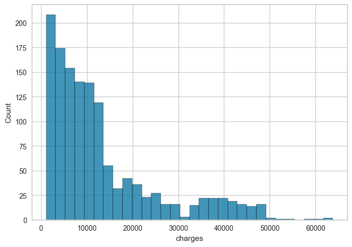

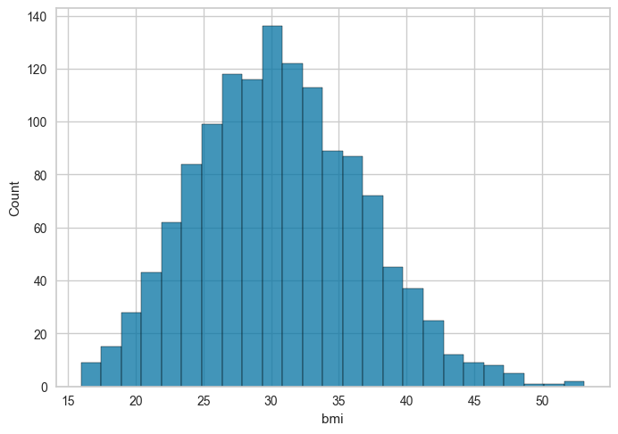

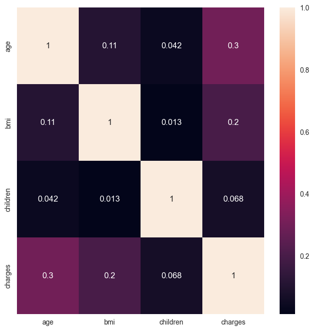

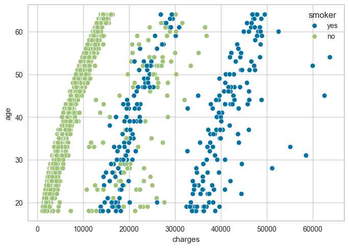

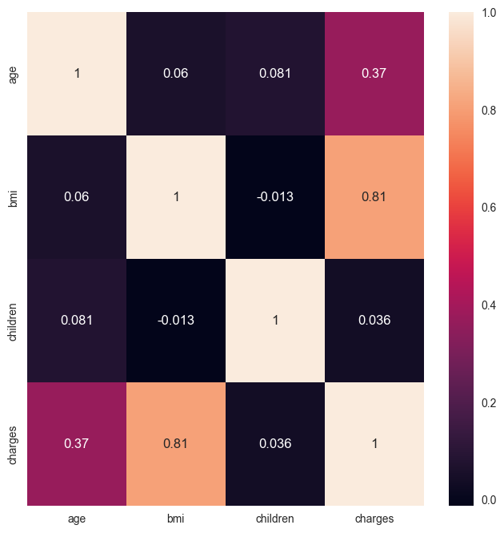

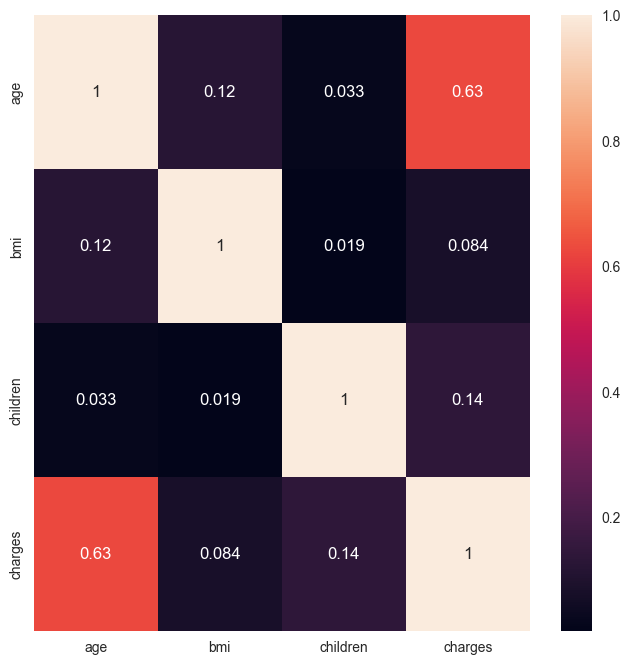

### Podczas wstępnej analizy danych zauważono:

- Bardzo silna dodatnia korelacja między bmi i charges u palaczy.
- Osoby palące mają znacznie wyższe średnie koszty (charges) niż niepalące.
- Wiek i liczba dzieci mają umiarkowany wpływ na koszt.
- Rozkład charges jest silnie skośny (long tail) – większość osób płaci poniżej 20 000, ale są obserwacje powyżej 50 000.

# Tworzenie modelu

|  | Model | MAE | MSE | RMSE | R2 | RMSLE | MAPE | TT (Sec) |
| --- | --- | --- | --- | --- | --- | --- | --- | --- |
| gbr | Gradient Boosting Regressor | 2701.9927 | 23548981.3626 | 4832.9682 | 0.8320 | 0.4447 | 0.3137 | 0.0370 |
| rf | Random Forest Regressor | 2771.4583 | 25416502.3827 | 5028.6343 | 0.8172 | 0.4690 | 0.3303 | 0.0740 |
| lightgbm | Light Gradient Boosting Machine | 2992.1828 | 25521038.3331 | 5042.0978 | 0.8149 | 0.5378 | 0.3751 | 0.0640 |
| et | Extra Trees Regressor | 2833.3624 | 28427844.2412 | 5305.6516 | 0.7991 | 0.4877 | 0.3363 | 0.0650 |
| ada | AdaBoost Regressor | 4316.0568 | 29220505.6498 | 5398.4561 | 0.7903 | 0.6368 | 0.7394 | 0.0210 |
| lar | Least Angle Regression | 4303.5559 | 38388058.4578 | 6176.5920 | 0.7306 | 0.5949 | 0.4433 | 0.0170 |
| llar | Lasso Least Angle Regression | 4303.7694 | 38386824.2786 | 6176.4846 | 0.7306 | 0.5952 | 0.4434 | 0.0180 |
| br | Bayesian Ridge | 4311.2349 | 38391950.0874 | 6176.8896 | 0.7306 | 0.5910 | 0.4447 | 0.0180 |
| ridge | Ridge Regression | 4317.6984 | 38396435.9578 | 6177.2329 | 0.7306 | 0.5891 | 0.4459 | 0.0170 |
| lasso | Lasso Regression | 4303.7697 | 38386797.6709 | 6176.4824 | 0.7306 | 0.5952 | 0.4434 | 0.0170 |
| lr | Linear Regression | 4303.5559 | 38388058.4578 | 6176.5920 | 0.7306 | 0.5949 | 0.4433 | 0.3720 |
| huber | Huber Regressor | 3463.2216 | 48801106.4612 | 6963.9984 | 0.6544 | 0.4927 | 0.2212 | 0.0240 |
| dt | Decision Tree Regressor | 3383.4916 | 47823199.0729 | 6895.7016 | 0.6497 | 0.5602 | 0.4013 | 0.0190 |
| par | Passive Aggressive Regressor | 4537.0122 | 67346309.9218 | 8142.7826 | 0.5422 | 0.5276 | 0.3207 | 0.0190 |
| en | Elastic Net | 7372.5238 | 90450782.5713 | 9468.3193 | 0.3792 | 0.7342 | 0.9184 | 0.0170 |
| omp | Orthogonal Matching Pursuit | 9089.9268 | 133439413.5272 | 11488.4238 | 0.0884 | 0.8790 | 1.1514 | 0.0200 |
| knn | K Neighbors Regressor | 8007.7997 | 131387268.8000 | 11425.3695 | 0.0859 | 0.8535 | 0.9232 | 0.0200 |
| dummy | Dummy Regressor | 9192.5418 | 148516792.8000 | 12132.4733 | -0.0175 | 1.0154 | 1.5637 | 0.0170 |

| Fold | MAE | MSE | RMSE | R2 | RMSLE | MAPE |
| --- | --- | --- | --- | --- | --- | --- |
| 0 | 2651.0179 | 20312968.8483 | 4506.9911 | 0.8787 | 0.4506 | 0.3416 |
| 1 | 3045.5971 | 31786370.9368 | 5637.9403 | 0.8152 | 0.4560 | 0.2991 |
| 2 | 2526.0336 | 22219684.6628 | 4713.7761 | 0.7187 | 0.4909 | 0.3007 |
| 3 | 2975.2686 | 23090143.9001 | 4805.2205 | 0.8072 | 0.4866 | 0.3810 |
| 4 | 2847.7050 | 27163724.2109 | 5211.8830 | 0.7980 | 0.5103 | 0.3367 |
| 5 | 2580.5742 | 19052273.4486 | 4364.8910 | 0.8774 | 0.3340 | 0.2437 |
| 6 | 2366.1844 | 19241130.1231 | 4386.4713 | 0.8691 | 0.3504 | 0.2649 |
| 7 | 2673.5009 | 25507898.8469 | 5050.5345 | 0.8597 | 0.4415 | 0.2750 |
| 8 | 2325.6224 | 18564300.1288 | 4308.6309 | 0.8801 | 0.3889 | 0.2888 |
| 9 | 3028.4227 | 28551318.5202 | 5343.3434 | 0.8161 | 0.5379 | 0.4058 |
| Mean | 2701.9927 | 23548981.3626 | 4832.9682 | 0.8320 | 0.4447 | 0.3137 |
| Std | 249.8136 | 4311102.3822 | 437.4926 | 0.0488 | 0.0643 | 0.0491 |

Porównałem wszystkie modele uczenia maszynowego i najlepsze wyniki osiągnął Gradient Boosting Regressor ze średnim MAE = 2702 oraz R2 = 0.832 na zbiorze testowym.

Za pomocą cross-validation wyliczyłem średnie metryki jakue osiąga model:

- MAE MSE RMSE R2
- 2702 23548981 4833 0.8320

|  | Model | MAE | MSE | RMSE | R2 | RMSLE | MAPE | TT (Sec) |
| --- | --- | --- | --- | --- | --- | --- | --- | --- |
| gbr | Gradient Boosting Regressor | 2786.5641 | 24556110.3907 | 4939.5463 | 0.8247 | 0.4852 | 0.3629 | 0.0300 |
| lightgbm | Light Gradient Boosting Machine | 3058.7291 | 26795026.7389 | 5167.7161 | 0.8056 | 0.5295 | 0.4047 | 0.0630 |
| ada | AdaBoost Regressor | 4110.9175 | 29364772.3726 | 5407.3721 | 0.7882 | 0.6229 | 0.6880 | 0.0150 |
| rf | Random Forest Regressor | 3054.9984 | 29360941.6379 | 5402.1609 | 0.7855 | 0.5423 | 0.4194 | 0.0620 |
| et | Extra Trees Regressor | 3229.5391 | 36263623.4816 | 5991.7584 | 0.7370 | 0.5697 | 0.4402 | 0.0480 |
| lar | Least Angle Regression | 4299.5003 | 38510828.7625 | 6187.4946 | 0.7298 | 0.6019 | 0.4509 | 0.0150 |
| llar | Lasso Least Angle Regression | 4299.9484 | 38510933.0031 | 6187.5003 | 0.7298 | 0.6014 | 0.4510 | 0.0130 |
| br | Bayesian Ridge | 4302.3398 | 38511657.6927 | 6187.5498 | 0.7298 | 0.6001 | 0.4514 | 0.0120 |
| ridge | Ridge Regression | 4313.4094 | 38517967.5621 | 6188.0074 | 0.7298 | 0.5973 | 0.4534 | 0.0190 |
| lasso | Lasso Regression | 4299.9484 | 38510933.0633 | 6187.5003 | 0.7298 | 0.6014 | 0.4510 | 0.0240 |
| lr | Linear Regression | 4299.5003 | 38510828.7625 | 6187.4946 | 0.7298 | 0.6019 | 0.4509 | 0.0150 |
| dt | Decision Tree Regressor | 3413.1516 | 44902694.8694 | 6648.0449 | 0.6626 | 0.6039 | 0.4706 | 0.0120 |
| huber | Huber Regressor | 3599.1703 | 48282383.1620 | 6926.7809 | 0.6583 | 0.4807 | 0.2445 | 0.0170 |
| par | Passive Aggressive Regressor | 4312.3369 | 70404450.5735 | 8310.2859 | 0.5258 | 0.5723 | 0.2421 | 0.0140 |
| en | Elastic Net | 7368.6822 | 90359716.1394 | 9465.0728 | 0.3794 | 0.7418 | 0.9331 | 0.0140 |
| knn | K Neighbors Regressor | 7394.2647 | 117458760.0000 | 10780.6500 | 0.1902 | 0.7723 | 0.7987 | 0.0160 |
| omp | Orthogonal Matching Pursuit | 9089.9268 | 133439413.5272 | 11488.4238 | 0.0884 | 0.8790 | 1.1514 | 0.0130 |
| dummy | Dummy Regressor | 9192.5418 | 148516792.8000 | 12132.4733 | -0.0175 | 1.0154 | 1.5637 | 0.0130 |

```
GradientBoostingRegressor(random_state=123)
```

Jak widzimy zignorowanie cech zmniejszyło dokładność więc pozostaniemy przy wcześniejszym modelu, Gradient Boosting Regressor nie wymaga skalowania cech natomiast sprawdzę czy inne modele nie osiągną lepszych wyników jeżeli tę czynnoś wykonamy

## Skalowanie i Transformacja

|  | Model | MAE | MSE | RMSE | R2 | RMSLE | MAPE | TT (Sec) |
| --- | --- | --- | --- | --- | --- | --- | --- | --- |
| gbr | Gradient Boosting Regressor | 2709.8932 | 23588432.7848 | 4837.1214 | 0.8317 | 0.4448 | 0.3140 | 0.0430 |
| rf | Random Forest Regressor | 2775.9960 | 25187210.9183 | 5005.7083 | 0.8189 | 0.4672 | 0.3297 | 0.0920 |
| lightgbm | Light Gradient Boosting Machine | 2989.9924 | 25501496.3256 | 5040.1491 | 0.8151 | 0.5377 | 0.3749 | 0.0730 |
| ada | AdaBoost Regressor | 4027.5901 | 27434830.4251 | 5223.5716 | 0.8048 | 0.6084 | 0.6709 | 0.0260 |
| et | Extra Trees Regressor | 2842.6220 | 28727552.6961 | 5332.7940 | 0.7971 | 0.4886 | 0.3372 | 0.0690 |
| lasso | Lasso Regression | 4385.9658 | 38630114.9345 | 6197.7076 | 0.7286 | 0.6124 | 0.4614 | 0.0220 |
| llar | Lasso Least Angle Regression | 4385.9832 | 38630108.1109 | 6197.7084 | 0.7286 | 0.6126 | 0.4614 | 0.0220 |
| lar | Least Angle Regression | 4384.0477 | 38632539.6135 | 6197.9595 | 0.7285 | 0.6063 | 0.4612 | 0.0340 |
| br | Bayesian Ridge | 4391.8477 | 38636856.1488 | 6198.2951 | 0.7285 | 0.6184 | 0.4626 | 0.0210 |
| lr | Linear Regression | 4384.0477 | 38632539.6135 | 6197.9595 | 0.7285 | 0.6063 | 0.4612 | 0.4060 |
| ridge | Ridge Regression | 5014.3983 | 45737976.5384 | 6737.4214 | 0.6839 | 0.5730 | 0.5767 | 0.0240 |
| dt | Decision Tree Regressor | 3300.9779 | 45902432.8352 | 6754.0465 | 0.6694 | 0.5579 | 0.3966 | 0.0270 |
| huber | Huber Regressor | 3999.1380 | 62204335.5831 | 7819.9187 | 0.5790 | 0.5267 | 0.2286 | 0.0290 |
| en | Elastic Net | 8993.4628 | 128221242.7866 | 11268.6506 | 0.1221 | 0.8661 | 1.1449 | 0.0220 |
| omp | Orthogonal Matching Pursuit | 9091.1852 | 133680735.6416 | 11498.7740 | 0.0869 | 0.8773 | 1.1436 | 0.0250 |
| knn | K Neighbors Regressor | 8526.4265 | 141205761.6000 | 11850.3201 | 0.0146 | 0.8965 | 1.0781 | 0.0400 |
| dummy | Dummy Regressor | 9192.5418 | 148516792.8000 | 12132.4733 | -0.0175 | 1.0154 | 1.5637 | 0.0220 |
| par | Passive Aggressive Regressor | 6870.7917 | 168780293.0535 | 12877.7987 | -0.1388 | 0.8949 | 0.3599 | 0.0220 |

|  | Model | MAE | MSE | RMSE | R2 | RMSLE | MAPE | TT (Sec) |
| --- | --- | --- | --- | --- | --- | --- | --- | --- |
| gbr | Gradient Boosting Regressor | 2704.9411 | 23567157.5677 | 4834.8275 | 0.8319 | 0.4448 | 0.3140 | 0.0380 |
| rf | Random Forest Regressor | 2772.7847 | 25379240.4648 | 5024.5579 | 0.8174 | 0.4685 | 0.3304 | 0.0780 |
| lightgbm | Light Gradient Boosting Machine | 2989.9577 | 25391993.0970 | 5029.6985 | 0.8157 | 0.5442 | 0.3750 | 0.0780 |
| et | Extra Trees Regressor | 2833.3624 | 28427844.2412 | 5305.6516 | 0.7991 | 0.4877 | 0.3363 | 0.0710 |
| ada | AdaBoost Regressor | 4198.3012 | 28689735.5532 | 5348.5728 | 0.7955 | 0.6291 | 0.7156 | 0.0230 |
| knn | K Neighbors Regressor | 3558.0286 | 33757213.4000 | 5798.2844 | 0.7605 | 0.4940 | 0.3628 | 0.0230 |
| lar | Least Angle Regression | 4303.5559 | 38388058.4578 | 6176.5920 | 0.7306 | 0.5949 | 0.4433 | 0.0200 |
| llar | Lasso Least Angle Regression | 4303.4005 | 38387422.4107 | 6176.5378 | 0.7306 | 0.5941 | 0.4433 | 0.0250 |
| br | Bayesian Ridge | 4308.1432 | 38390146.8642 | 6176.7504 | 0.7306 | 0.5869 | 0.4443 | 0.0200 |
| ridge | Ridge Regression | 4305.1268 | 38388171.4400 | 6176.5963 | 0.7306 | 0.5911 | 0.4437 | 0.0190 |
| lasso | Lasso Regression | 4303.4017 | 38387401.4350 | 6176.5362 | 0.7306 | 0.5941 | 0.4433 | 0.0200 |
| lr | Linear Regression | 4303.6819 | 38419036.6612 | 6179.2776 | 0.7304 | 0.5929 | 0.4428 | 0.0210 |
| en | Elastic Net | 5224.6376 | 50299445.1891 | 7060.8052 | 0.6547 | 0.6303 | 0.7145 | 0.0200 |
| dt | Decision Tree Regressor | 3361.1752 | 47258683.2585 | 6854.0584 | 0.6531 | 0.5588 | 0.4002 | 0.0200 |
| huber | Huber Regressor | 3460.8681 | 49278886.8675 | 6997.6208 | 0.6512 | 0.4837 | 0.2193 | 0.0210 |
| par | Passive Aggressive Regressor | 3459.1109 | 49702604.9557 | 7028.0299 | 0.6482 | 0.4846 | 0.2169 | 0.0220 |
| omp | Orthogonal Matching Pursuit | 5754.7769 | 57503207.7233 | 7566.7086 | 0.5997 | 0.7418 | 0.8990 | 0.0190 |
| dummy | Dummy Regressor | 9192.5418 | 148516792.8000 | 12132.4733 | -0.0175 | 1.0154 | 1.5637 | 0.0210 |

Modele z przeskalowanymi danymi nie osiągnęły lepszych wyników dlatego zostaniemy przy standardowym

## Tuning modelu

| Fold | MAE | MSE | RMSE | R2 | RMSLE | MAPE |
| --- | --- | --- | --- | --- | --- | --- |
| 0 | 2805.0014 | 21582126.3603 | 4645.6567 | 0.8711 | 0.5684 | 0.3722 |
| 1 | 3040.9335 | 30629969.6487 | 5534.4349 | 0.8219 | 0.4491 | 0.3076 |
| 2 | 2926.1972 | 25171972.5036 | 5017.1678 | 0.6813 | 0.5599 | 0.3686 |
| 3 | 3051.2084 | 24837489.9354 | 4983.7225 | 0.7926 | 0.5310 | 0.4751 |
| 4 | 3107.7744 | 27994343.2274 | 5290.9681 | 0.7918 | 0.5223 | 0.3451 |
| 5 | 2897.4816 | 21570269.9006 | 4644.3805 | 0.8612 | 0.3977 | 0.3015 |
| 6 | 2608.7777 | 21868894.3542 | 4676.4190 | 0.8512 | 0.3893 | 0.2988 |
| 7 | 2775.1669 | 27053940.9948 | 5201.3403 | 0.8512 | 0.4914 | 0.2676 |
| 8 | 2568.6294 | 18962398.2741 | 4354.5836 | 0.8775 | 0.4676 | 0.3868 |
| 9 | 2937.2306 | 27500799.7123 | 5244.1205 | 0.8229 | 0.5309 | 0.3838 |
| Mean | 2871.8401 | 24717220.4911 | 4959.2794 | 0.8223 | 0.4908 | 0.3507 |
| Std | 172.9943 | 3465444.1261 | 350.3834 | 0.0551 | 0.0602 | 0.0571 |

```
Fitting 10 folds for each of 50 candidates, totalling 500 fits
Original model was better than the tuned model, hence it will be returned. NOTE: The display metrics are for the tuned model (not the original one).
```

O dziwo model poradził sobie gorzej niż jego klasyczna wersja

# Poniżej ręcznie ustawiałem Model Gradient Boosting Regressor

Porównam go za pomocą MlFlow

```
2025/07/29 23:18:44 INFO mlflow.tracking.fluent: Experiment with name 'Model przewidujący ceny ubezpieczeń' does not exist. Creating a new experiment.
```

```
<Experiment: artifact_location='mlflow-artifacts:/702798114049330542', creation_time=1753823924352, experiment_id='702798114049330542', last_update_time=1753823924352, lifecycle_stage='active', name='Model przewidujący ceny ubezpieczeń', tags={}>
```

```
Srednie MAE -2740.8097566329457
Średni R2: 0.8305515807338194
```

```
Successfully registered model 'Gradient_boosting'.
2025/07/29 23:19:11 INFO mlflow.tracking._model_registry.client: Waiting up to 300 seconds for model version to finish creation. Model name: Gradient_boosting, version 1
Created version '1' of model 'Gradient_boosting'.
```

```
Best params: {'learning_rate': 0.05, 'max_depth': 3, 'min_samples_leaf': 3, 'min_samples_split': 2, 'n_estimators': 100}
```

```
Srednie MAE -2667.1395477474766
Średni R²: 0.8389467154806795
```

```
Registered model 'Gradient_boosting' already exists. Creating a new version of this model...
2025/07/29 23:19:21 INFO mlflow.tracking._model_registry.client: Waiting up to 300 seconds for model version to finish creation. Model name: Gradient_boosting, version 2
Created version '2' of model 'Gradient_boosting'.
```

Wyniki modelu po dostrojeniu hiperparametrów się polepszyły, porównując z wszystkimi modelami można go uznać za najlepszy

## Full Pipeline

|  | age | sex | bmi | children | smoker | region | charges |
| --- | --- | --- | --- | --- | --- | --- | --- |
| 0 | 19 | female | 27.900 | 0 | yes | southwest | 16884.92400 |
| 1 | 18 | male | 33.770 | 1 | no | southeast | 1725.55230 |
| 2 | 28 | male | 33.000 | 3 | no | southeast | 4449.46200 |
| 3 | 33 | male | 22.705 | 0 | no | northwest | 21984.47061 |
| 4 | 32 | male | 28.880 | 0 | no | northwest | 3866.85520 |

```
Pipeline(steps=[('preprocessing',
                 ColumnTransformer(remainder='passthrough',
                                   transformers=[('cat',
                                                  OneHotEncoder(drop='first'),
                                                  ['sex', 'smoker',
                                                   'region'])])),
                ('model',
                 GradientBoostingRegressor(learning_rate=0.05,
                                           min_samples_leaf=3,
                                           random_state=42))])
```

```
['insurance_model.pkl']
```

```
Predicted charges: 7023.357913176589
```